# Predicting Consumer Behavior During Black Friday Season

Qiao Han/Shpakova Anastasiya/Shuangmu Feng/Yucheng Zhang

2019/4/24

## Predicting Consumer Behavior During Black Friday Season

### Source of our data

A copy of or link to the data you plan to use https://www.kaggle.com/mehdidag/black-friday

[figure not shown]

A Typical Black Friday Situation

## Introduction

- The dataset
  - Data collected from a retail store during Black Friday month
  - High degree of anonymity maintained - many details are hidden!
- Independent variables
  - Product info: product IDs (masked), category of products purchased (masked)
  - Basic demographic data: age, gender, marital status, occupation (masked), type of current city (masked), length of staying in their city
- Our goal is to predict how much a given consumer will spend during Black Friday season
  - Approach 1: Dependent variable: Spending Amount Bucket (split at the median) for Total Purchase by Unique Consumer
  - Approach 2: Dependent variable: Individual Purchase Amount based on Consumer Info (product and consumer ID hidden)

## Qick Look at the Dataset

```
## [1] 537577     12
```

| User_ID | Product_ID | Gender | Age | Occupation | City_Category | Stay_In_Current_City_Years | Marital_Status | Product_Category_1 | Product_Category_2 | Product_Category_3 | Purchase |
| --- | --- | --- | --- | --- | --- | --- | --- | --- | --- | --- | --- |
| 1000001 | P00069042 | F | 0-17 | 10 | A | 2 | 0 | 3 |  |  | 8370 |
| 1000001 | P00248942 | F | 0-17 | 10 | A | 2 | 0 | 1 | 6 | 14 | 15200 |
| 1000001 | P00087842 | F | 0-17 | 10 | A | 2 | 0 | 12 |  |  | 1422 |
| 1000001 | P00085442 | F | 0-17 | 10 | A | 2 | 0 | 12 | 14 |  | 1057 |
| 1000002 | P00285442 | M | 55+ | 16 | C | 4+ | 0 | 8 |  |  | 7969 |
| 1000003 | P00193542 | M | 26-35 | 15 | A | 3 | 0 | 1 | 2 |  | 15227 |

Data dimensions: 537577 rows x 12

## Our Strategy

1. Exploratory Data Analysis
2. Data Cleaning
3. Analysis / Modeling Stage
4. Conclusion

## I. Exploratory Data Analysis

A. Simple Statistics B. Population Distribution

## EDA: Count Unique Instances of Variables

|  | V1 |
| --- | --- |
| User_ID | 5891 |
| Product_ID | 3623 |
| Gender | 2 |
| Age | 7 |
| Occupation | 21 |
| City_Category | 3 |
| Stay_In_Current_City_Years | 5 |
| Marital_Status | 2 |
| Product_Category_1 | 18 |
| Product_Category_2 | 18 |

[output cut: 2 more lines]

## A. Simple Statistics

  | User_ID | N_Purchases | Mean | Max | Sum |
  | --- | --- | --- | --- | --- |
  | 1004277 | 978 | 10773.81 | 23615 | 10536783 |
  | 1001680 | 1025 | 8487.06 | 23631 | 8699232 |
  | 1002909 | 717 | 10568.35 | 23446 | 7577505 |
  | 1001941 | 898 | 7591.86 | 21160 | 6817493 |
  | 1000424 | 694 | 9472.06 | 23733 | 6573609 |
  | 1004448 | 574 | 11438.81 | 23050 | 6565878 |
  | 1001015 | 739 | 8810.96 | 23591 | 6511302 |
  | 1003391 | 697 | 9292.38 | 23883 | 6476786 |
  | 1001181 | 861 | 7419.16 | 23579 | 6387899 |
  | 1000549 | 631 | 10000.96 | 23852 | 6310604 |

  [output cut: 5881 more lines]

## B. Population Distribution

## Age Status

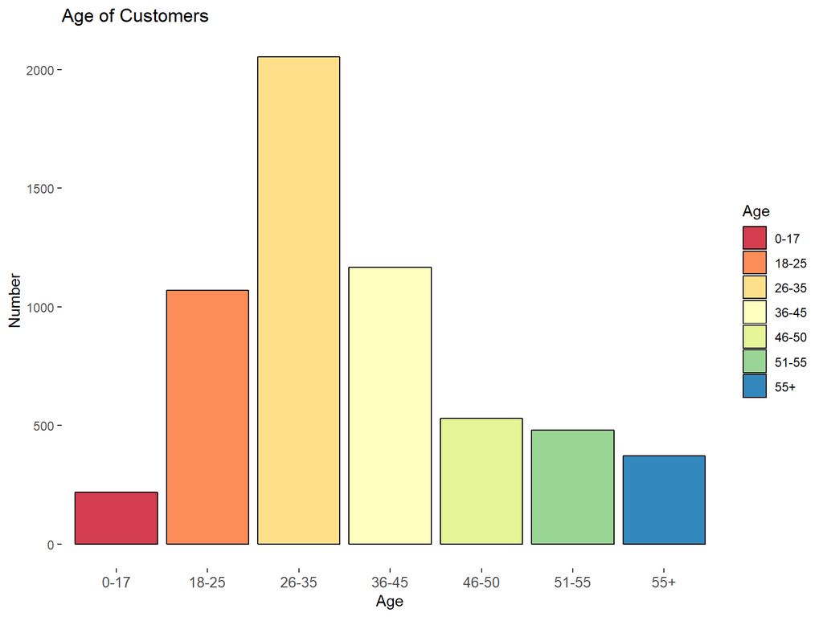

## Gender Distribution

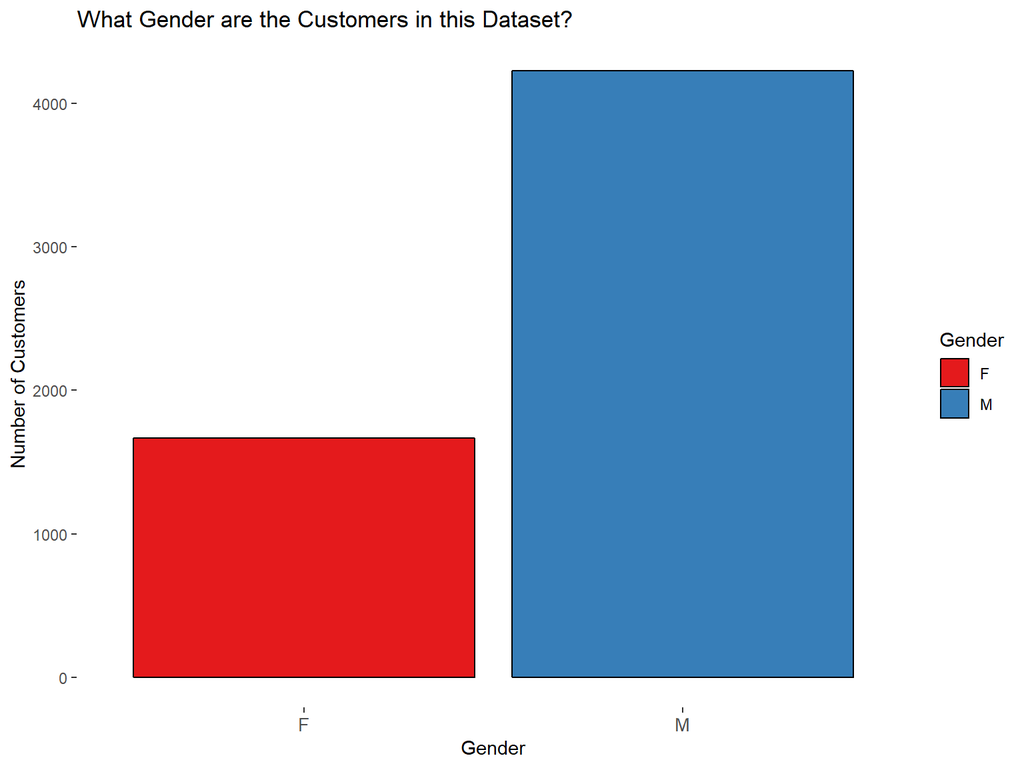

## Marital Status Distribution

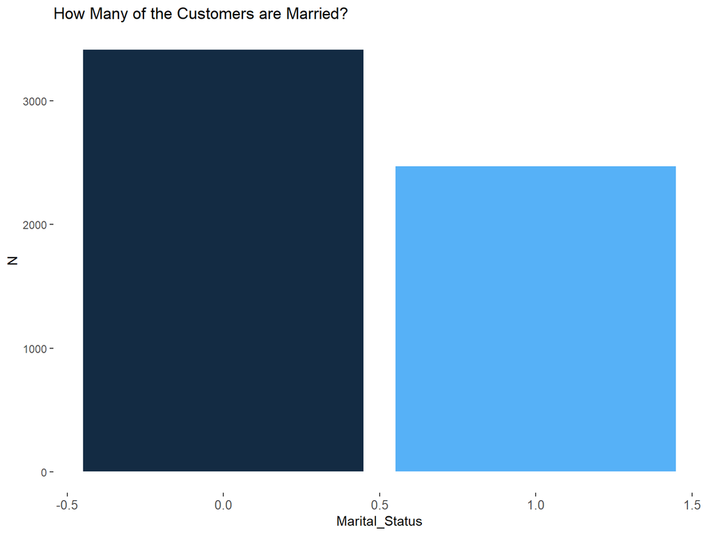

## Average Purchase Amount by City and Gender Status

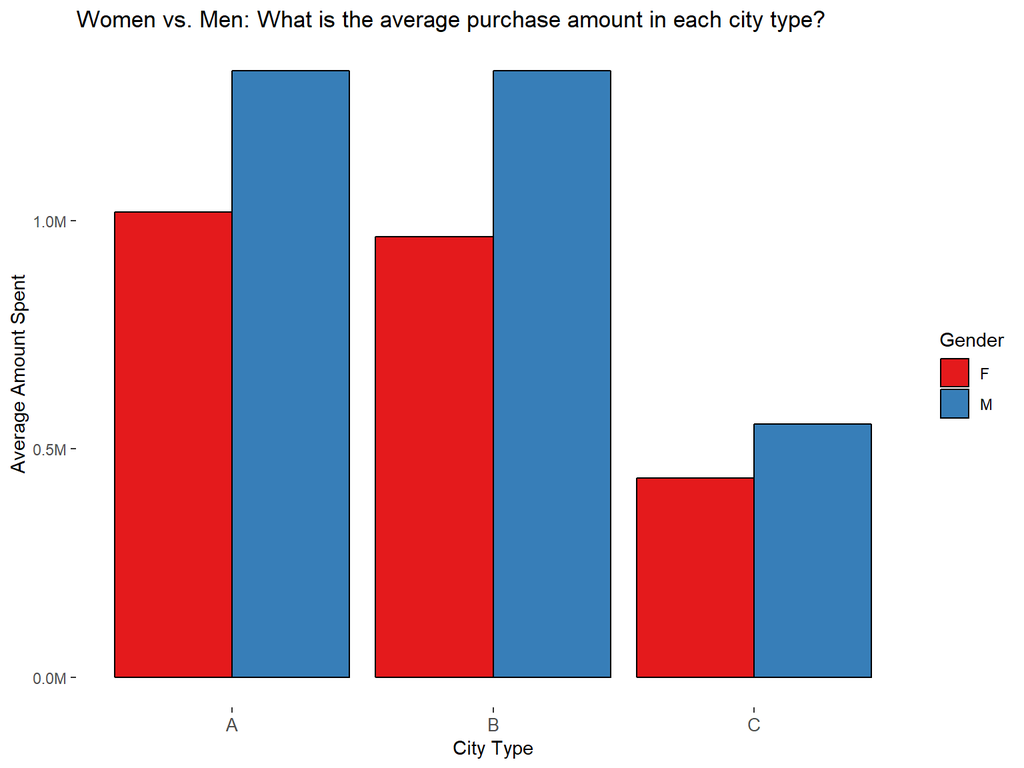

```
##    City_Category Gender  purchase
## 1:             A      F 1018343.3
## 2:             A      M 1327010.0
## 3:             B      F  964836.5
## 4:             B      M 1327341.2
## 5:             C      F  436520.7
## 6:             C      M  554675.5
```

## Distribution of Sending By Age

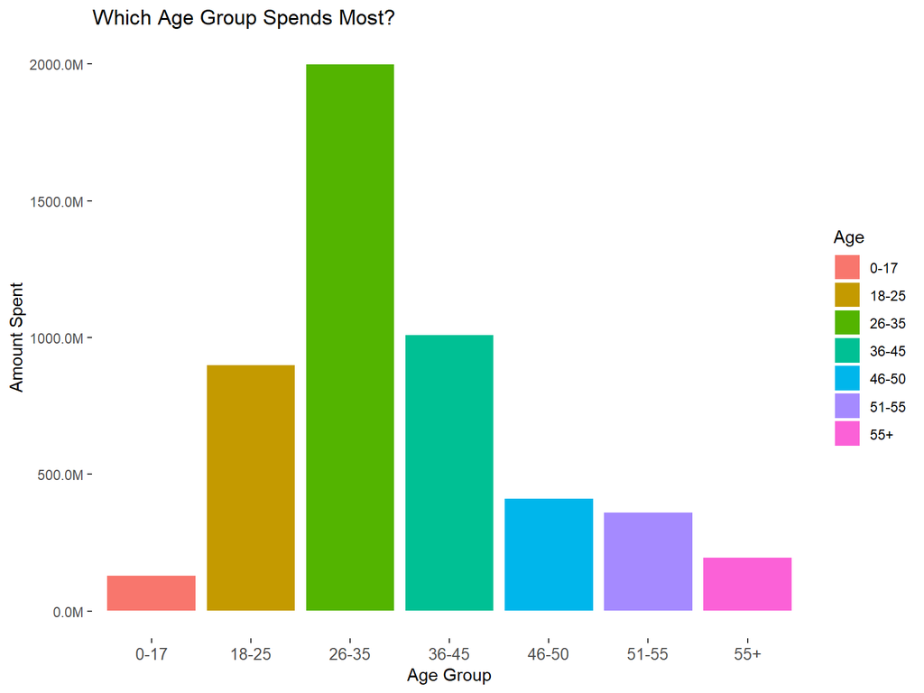

## Distribution of Sending by City Type

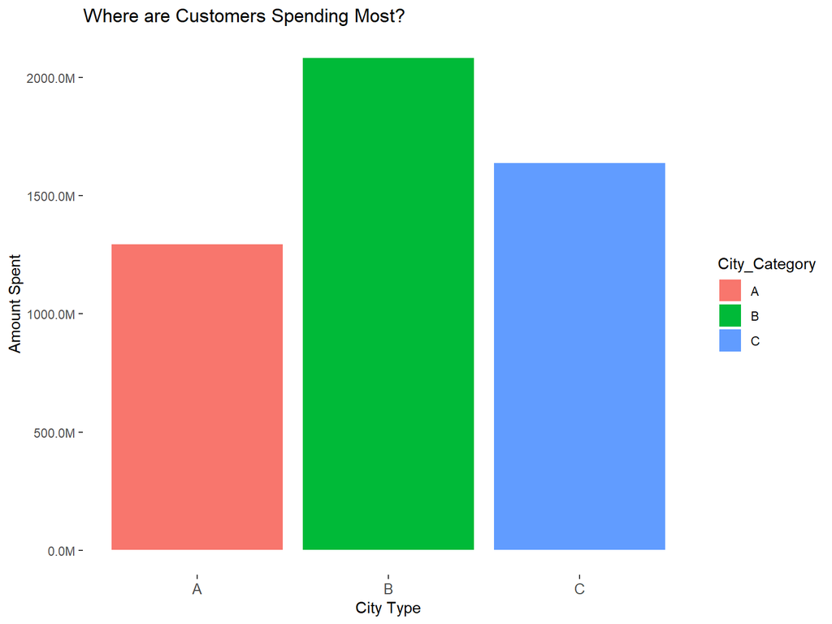

## Total Purchase by City and Age Group

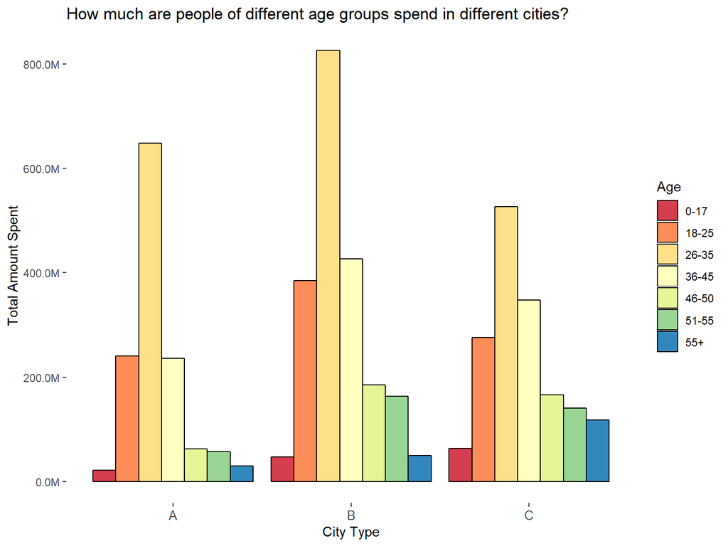

## Purchase By Gender

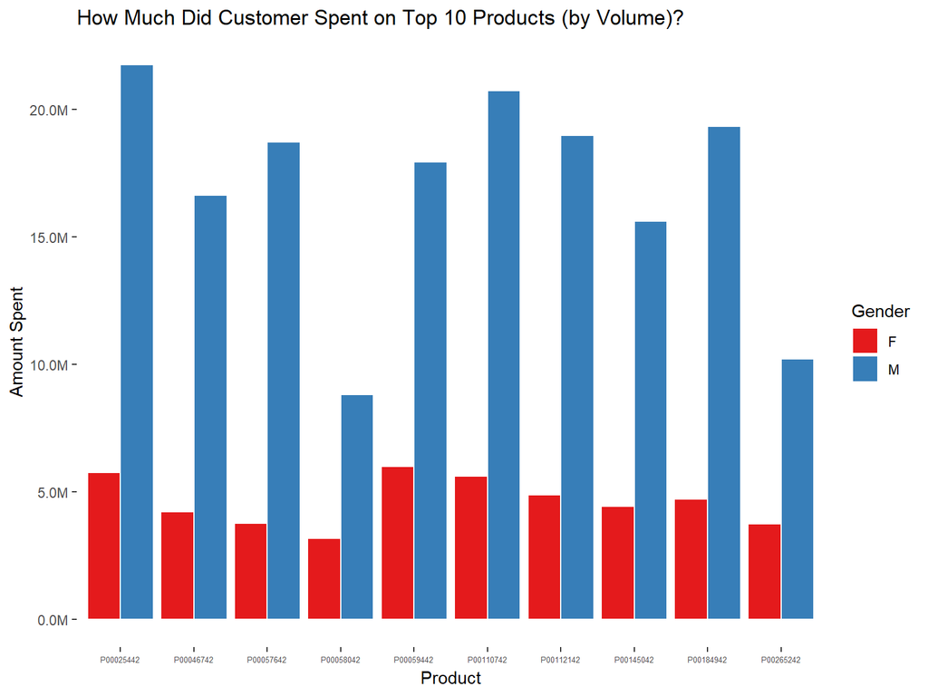

## Top Ten Purchase by City

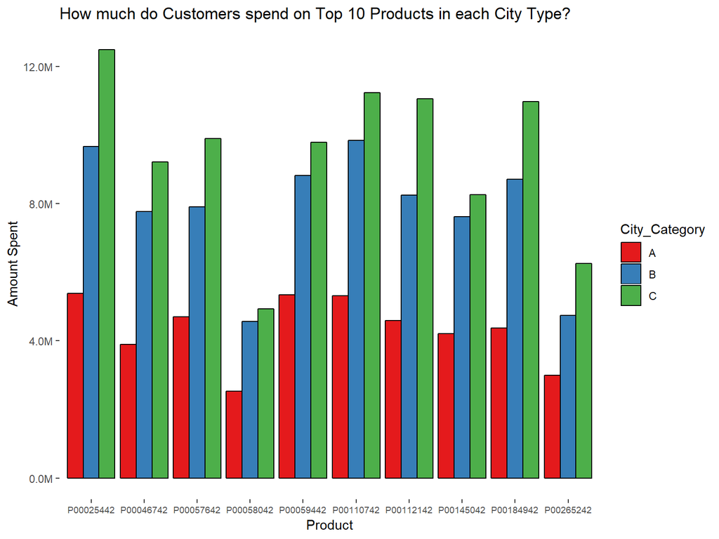

## Top Ten Purchase by Age

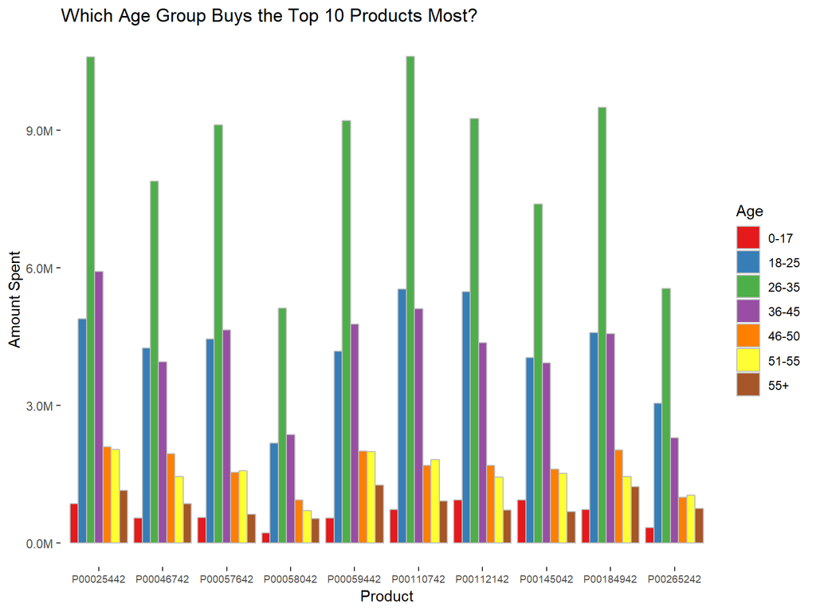

## END of EDA

## II. Data Cleaning Stage

## Modeling - Data Cleaning

- Cleaning (get the new refined dataset)
- Filter data for Top 10 products (~15K rows)
- N/A: replace all N/A with 0 (product cat 2 and 3)
- Convert age, gender and city to 1, 2, 3
- Stay_In_Current_City_Years - convert 4+ to 4
- Ignore the Product Category columns 1-3 (drop)

```
##    Occupation Marital_Status Gen Age17 Age25 Age35 Age45 Age55 CityA CityB
## 1:         10              0   0     1     0     0     0     0     1     0
## 2:         16              0   1     0     0     0     0     0     0     0
## 3:         15              0   1     0     0     1     0     0     1     0
## 4:          7              1   1     0     0     0     0     0     0     1
## 5:         20              1   1     0     0     1     0     0     1     0
## 6:          9              0   0     0     0     0     0     1     1     0
##    Currentyears1 Currentyears2 Currentyears3 Currentyears4
## 1:             0             1             0             0
## 2:             0             0             0             1
## 3:             0             0             1             0
## 4:             0             1             0             0
## 5:             1             0             0             0
## 6:             1             0             0             0
##              pur.group
## 1: [   44108,  512612)
## 2: [  512612,10536783]
## 3: [   44108,  512612)
## 4: [   44108,  512612)
## 5: [  512612,10536783]
## 6: [   44108,  512612)
```

## Sample Data

## Modeling

## 1.Random forest

```
## [   44108,  512612) [  512612,10536783]
##                 239                 350
```

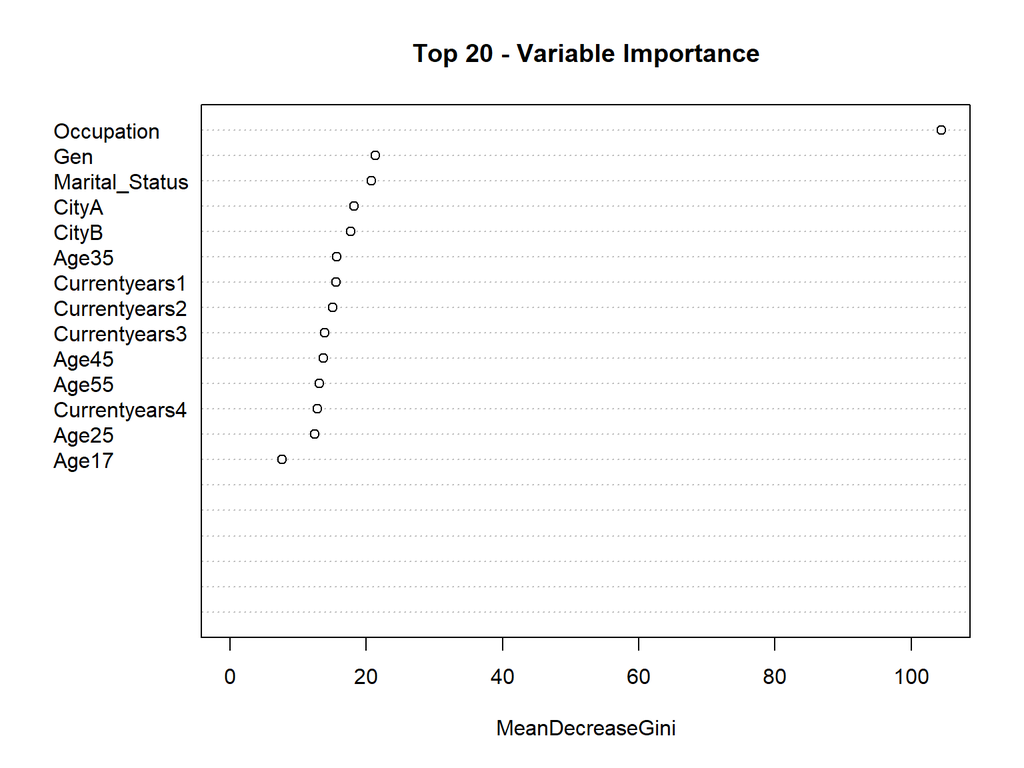

```
## [1] 0.6434635
```

## multinomial logistic regression

```
## [   44108,  512612) [  512612,10536783]
##                 332                 257
```

```
## [1] 0.4957555
```

## ROC

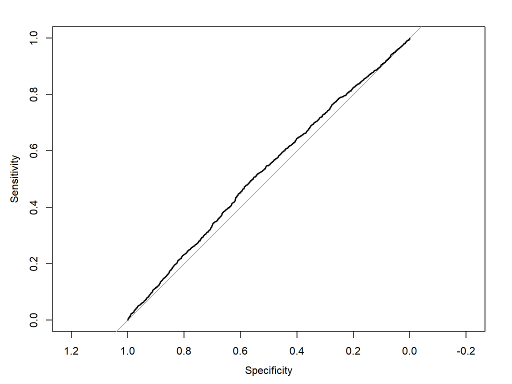

```
## Area under the curve: 0.5289
```

## KNN

```
## [   44108,  512612) [  512612,10536783]
##                 286                 303
```

```
## [1] 0.6383701
```

```
## [1] 0.6655348
```